# Aim: To build a Python model that can predict if an existing customer is more likely to buy a new car using Logistic Regression

## 0.Import Packages

```python
! pip install -r https://raw.githubusercontent.com/aso-uts/labs_datasets/main/36106-mlaa/requirements.txt
```

```python
import pandas as pd
import numpy as np
import matplotlib.pyplot as plt
import seaborn as sns
from sklearn.model_selection import train_test_split
from sklearn.preprocessing import LabelEncoder
from sklearn.metrics import accuracy_score, precision_score, recall_score, f1_score, roc_auc_score
from sklearn.model_selection import KFold
from sklearn.model_selection import cross_val_score
import warnings
warnings.filterwarnings("ignore")
```

## 1. Load data

```python
data = pd.read_csv("C:\\Users\\shiva\\Downloads\\repurchase_dataset.csv")
```

## 2. Explore dataset

```python
data.info()
```

```
<class 'pandas.core.frame.DataFrame'>
RangeIndex: 131337 entries, 0 to 131336
Data columns (total 17 columns):
 #   Column                     Non-Null Count   Dtype
---  ------                     --------------   -----
 0   ID                         131337 non-null  int64
 1   Target                     131337 non-null  int64
 2   age_band                   18962 non-null   object
 3   gender                     62029 non-null   object
 4   car_model                  131337 non-null  object
 5   car_segment                131337 non-null  object
 6   age_of_vehicle_years       131337 non-null  int64
 7   sched_serv_warr            131337 non-null  int64
 8   non_sched_serv_warr        131337 non-null  int64
 9   sched_serv_paid            131337 non-null  int64
 10  non_sched_serv_paid        131337 non-null  int64
 11  total_paid_services        131337 non-null  int64
 12  total_services             131337 non-null  int64
 13  mth_since_last_serv        131337 non-null  int64
 14  annualised_mileage         131337 non-null  int64
 15  num_dealers_visited        131337 non-null  int64
 16  num_serv_dealer_purchased  131337 non-null  int64
dtypes: int64(13), object(4)
memory usage: 17.0+ MB
```

```python
data.head()
```

|  | ID | Target | age_band | gender | car_model | car_segment | age_of_vehicle_years | sched_serv_warr | non_sched_serv_warr | sched_serv_paid | non_sched_serv_paid | total_paid_services | total_services | mth_since_last_serv | annualised_mileage | num_dealers_visited | num_serv_dealer_purchased |
| --- | --- | --- | --- | --- | --- | --- | --- | --- | --- | --- | --- | --- | --- | --- | --- | --- | --- |
| 0 | 1 | 0 | 3. 35 to 44 | Male | model_1 | LCV | 9 | 2 | 10 | 3 | 7 | 5 | 6 | 9 | 8 | 10 | 4 |
| 1 | 2 | 0 | NaN | NaN | model_2 | Small/Medium | 6 | 10 | 3 | 10 | 4 | 9 | 10 | 6 | 10 | 7 | 10 |
| 2 | 3 | 0 | NaN | Male | model_3 | Large/SUV | 9 | 10 | 9 | 10 | 9 | 10 | 10 | 7 | 10 | 6 | 10 |
| 3 | 5 | 0 | NaN | NaN | model_3 | Large/SUV | 5 | 8 | 5 | 8 | 4 | 5 | 6 | 4 | 10 | 9 | 7 |
| 4 | 6 | 0 | NaN | Female | model_2 | Small/Medium | 8 | 9 | 4 | 10 | 7 | 9 | 8 | 5 | 4 | 4 | 9 |

```python
data.tail()
```

|  | ID | Target | age_band | gender | car_model | car_segment | age_of_vehicle_years | sched_serv_warr | non_sched_serv_warr | sched_serv_paid | non_sched_serv_paid | total_paid_services | total_services | mth_since_last_serv | annualised_mileage | num_dealers_visited | num_serv_dealer_purchased |
| --- | --- | --- | --- | --- | --- | --- | --- | --- | --- | --- | --- | --- | --- | --- | --- | --- | --- |
| 131332 | 154134 | 1 | NaN | NaN | model_3 | Large/SUV | 7 | 10 | 10 | 9 | 10 | 10 | 10 | 3 | 6 | 10 | 10 |
| 131333 | 154135 | 1 | NaN | NaN | model_3 | Large/SUV | 4 | 10 | 10 | 10 | 10 | 10 | 10 | 2 | 3 | 10 | 10 |
| 131334 | 154137 | 1 | NaN | NaN | model_5 | Large/SUV | 4 | 4 | 9 | 5 | 4 | 3 | 8 | 4 | 7 | 10 | 10 |
| 131335 | 154138 | 1 | NaN | NaN | model_5 | Large/SUV | 2 | 1 | 10 | 1 | 10 | 9 | 8 | 3 | 6 | 7 | 10 |
| 131336 | 154139 | 1 | NaN | NaN | model_1 | LCV | 6 | 1 | 7 | 1 | 10 | 10 | 5 | 3 | 4 | 9 | 10 |

```python
data.describe()
```

|  | ID | Target | age_of_vehicle_years | sched_serv_warr | non_sched_serv_warr | sched_serv_paid | non_sched_serv_paid | total_paid_services | total_services | mth_since_last_serv | annualised_mileage | num_dealers_visited | num_serv_dealer_purchased |
| --- | --- | --- | --- | --- | --- | --- | --- | --- | --- | --- | --- | --- | --- |
| count | 131337.000000 | 131337.000000 | 131337.000000 | 131337.000000 | 131337.000000 | 131337.000000 | 131337.000000 | 131337.000000 | 131337.000000 | 131337.000000 | 131337.000000 | 131337.000000 | 131337.000000 |
| mean | 77097.384180 | 0.026809 | 5.493022 | 5.452500 | 5.472517 | 5.452287 | 5.497050 | 5.481692 | 5.454967 | 5.469807 | 5.502836 | 5.485438 | 5.480778 |
| std | 44501.636704 | 0.161525 | 2.843299 | 2.884328 | 2.870665 | 2.886528 | 2.878699 | 2.880408 | 2.875961 | 2.859756 | 2.854896 | 2.876772 | 2.867524 |
| min | 1.000000 | 0.000000 | 1.000000 | 1.000000 | 1.000000 | 1.000000 | 1.000000 | 1.000000 | 1.000000 | 1.000000 | 1.000000 | 1.000000 | 1.000000 |
| 25% | 38563.000000 | 0.000000 | 3.000000 | 3.000000 | 3.000000 | 3.000000 | 3.000000 | 3.000000 | 3.000000 | 3.000000 | 3.000000 | 3.000000 | 3.000000 |
| 50% | 77132.000000 | 0.000000 | 5.000000 | 5.000000 | 5.000000 | 5.000000 | 5.000000 | 5.000000 | 5.000000 | 5.000000 | 5.000000 | 5.000000 | 5.000000 |
| 75% | 115668.000000 | 0.000000 | 8.000000 | 8.000000 | 8.000000 | 8.000000 | 8.000000 | 8.000000 | 8.000000 | 8.000000 | 8.000000 | 8.000000 | 8.000000 |
| max | 154139.000000 | 1.000000 | 10.000000 | 10.000000 | 10.000000 | 10.000000 | 10.000000 | 10.000000 | 10.000000 | 10.000000 | 10.000000 | 10.000000 | 10.000000 |

```python
print("Number of rows", data.shape[0])
print("Number of columns", data.shape[1])
```

```
Number of rows 131337
Number of columns 17
```

```python
print(data.dtypes)
```

```
ID                            int64
Target                        int64
age_band                     object
gender                       object
car_model                    object
car_segment                  object
age_of_vehicle_years          int64
sched_serv_warr               int64
non_sched_serv_warr           int64
sched_serv_paid               int64
non_sched_serv_paid           int64
total_paid_services           int64
total_services                int64
mth_since_last_serv           int64
annualised_mileage            int64
num_dealers_visited           int64
num_serv_dealer_purchased     int64
dtype: object
```

## 3. Explore Target Variable

```python
target = 'Target'
```

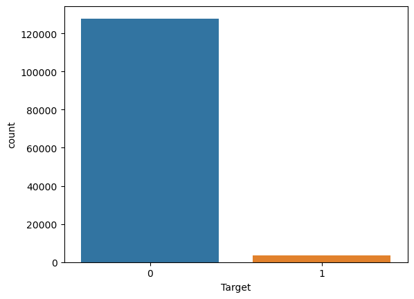

```python
import seaborn as sns
import matplotlib.pyplot as plt

# count plot on single categorical variable
sns.countplot(x =target, data = data)

# Show the plot
plt.show()
```

## 4. Explore variable of interest

### Numerical Features

```python
# Compute summary statistics for numerical features
numerical_summary = data.describe().transpose()
numerical_summary
```

|  | count | mean | std | min | 25% | 50% | 75% | max |
| --- | --- | --- | --- | --- | --- | --- | --- | --- |
| ID | 131337.0 | 77097.384180 | 44501.636704 | 1.0 | 38563.0 | 77132.0 | 115668.0 | 154139.0 |
| Target | 131337.0 | 0.026809 | 0.161525 | 0.0 | 0.0 | 0.0 | 0.0 | 1.0 |
| age_of_vehicle_years | 131337.0 | 5.493022 | 2.843299 | 1.0 | 3.0 | 5.0 | 8.0 | 10.0 |
| sched_serv_warr | 131337.0 | 5.452500 | 2.884328 | 1.0 | 3.0 | 5.0 | 8.0 | 10.0 |
| non_sched_serv_warr | 131337.0 | 5.472517 | 2.870665 | 1.0 | 3.0 | 5.0 | 8.0 | 10.0 |
| sched_serv_paid | 131337.0 | 5.452287 | 2.886528 | 1.0 | 3.0 | 5.0 | 8.0 | 10.0 |
| non_sched_serv_paid | 131337.0 | 5.497050 | 2.878699 | 1.0 | 3.0 | 5.0 | 8.0 | 10.0 |
| total_paid_services | 131337.0 | 5.481692 | 2.880408 | 1.0 | 3.0 | 5.0 | 8.0 | 10.0 |
| total_services | 131337.0 | 5.454967 | 2.875961 | 1.0 | 3.0 | 5.0 | 8.0 | 10.0 |
| mth_since_last_serv | 131337.0 | 5.469807 | 2.859756 | 1.0 | 3.0 | 5.0 | 8.0 | 10.0 |
| annualised_mileage | 131337.0 | 5.502836 | 2.854896 | 1.0 | 3.0 | 5.0 | 8.0 | 10.0 |
| num_dealers_visited | 131337.0 | 5.485438 | 2.876772 | 1.0 | 3.0 | 5.0 | 8.0 | 10.0 |
| num_serv_dealer_purchased | 131337.0 | 5.480778 | 2.867524 | 1.0 | 3.0 | 5.0 | 8.0 | 10.0 |

##### Exploring numerical features

```python
# Selecting numerical features
numerical_features = data.select_dtypes(include=['int64'])
```

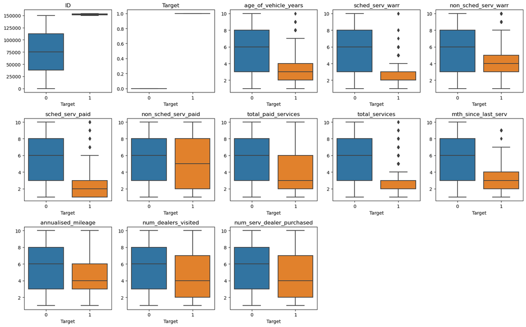

```python
# Plotting boxplots for numerical features
plt.figure(figsize=(16, 10))
for i, col in enumerate(numerical_features.columns):
    plt.subplot(3, 5, i + 1)
    sns.boxplot(data=data, x='Target', y=col)
    plt.title(col)
    plt.xlabel('Target')
    plt.ylabel('')
plt.tight_layout()
plt.show()
```

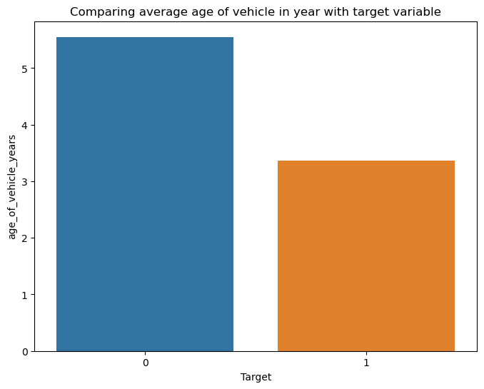

```python
plt.figure(figsize=(8,6))
sns.barplot(x="Target",y="age_of_vehicle_years",data=data,ci= False)
plt.title("Comparing average age of vehicle in year with target variable")
plt.show()
```

### Hypothesis testing

#### Applying statistical t-test to determine the realtionship between average age vehicle vs target variable.

```python
from scipy.stats import ttest_ind
age_target1 = data[data["Target"] == 1]["age_of_vehicle_years"]
age_target0 = data[data["Target"] == 0]["age_of_vehicle_years"]

# applying t-test
stat,p = ttest_ind(age_target1,age_target0)
if p > 0.05:
    print("P-value {}".format(p))
    print(" cannot reject the null hypothesis.There is no difference in the average age of vehicle with respect to target variable")
else:
    print("P-value {}".format(p))
    print("reject the null hypothesis.There is  difference in the average age of vehicle with respect to target variable")
```

```
P-value 0.0
reject the null hypothesis.There is  difference in the average age of vehicle with respect to target variable
```

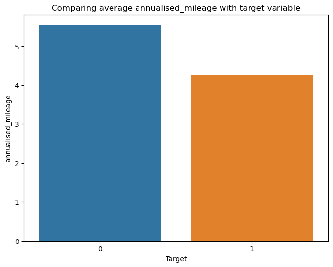

```python
# seaborn bar plot gives the variable average
plt.figure(figsize=(8,6))
sns.barplot(x="Target",y="annualised_mileage",data=data,ci= False)
plt.title("Comparing average annualised_mileage with target variable")
plt.show()
```

### Hypothesis testing

```python
from scipy.stats import ttest_ind
age_target1 = data[data["Target"] == 1]["annualised_mileage"]
age_target0 = data[data["Target"] == 0]["annualised_mileage"]

# applying t-test
stat,p = ttest_ind(age_target1,age_target0)
if p > 0.05:
    print("P-value {}".format(p))
    print(" cannot reject the null hypothesis.There is no difference in the annualised_mileage of vehicle with respect to target variable")
else:
    print("P-value {}".format(p))
    print("reject the null hypothesis.There is  difference in the annualised_mileage of vehicle with respect to target variable")
```

```
P-value 7.325276269854025e-155
reject the null hypothesis.There is  difference in the annualised_mileage of vehicle with respect to target variable
```

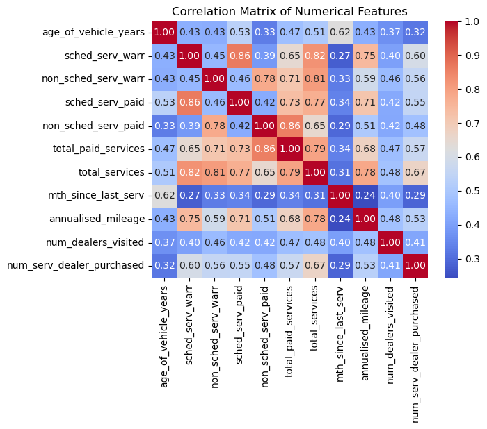

```python
numerical_features = ['age_of_vehicle_years', 'sched_serv_warr', 'non_sched_serv_warr', 'sched_serv_paid', 'non_sched_serv_paid', 'total_paid_services', 'total_services', 'mth_since_last_serv', 'annualised_mileage', 'num_dealers_visited', 'num_serv_dealer_purchased']

# Select only the numerical features from the DataFrame
numerical_data = data[numerical_features]

# Compute the correlation matrix
correlation_matrix = numerical_data.corr()

# Plot the correlation matrix using a heatmap
sns.heatmap(correlation_matrix, annot=True, cmap='coolwarm', fmt=".2f")
plt.title('Correlation Matrix of Numerical Features')
plt.show()
```

##### Correlation Matrix of Numerical Features'

### Categorial Features

```python
# categorical summary
categorical_features = data.select_dtypes(include=['object'])

# Generate summary statistics for categorical features
categorical_summary = categorical_features.describe(include=['object']).transpose()
print(categorical_summary)
```

```
              count unique           top   freq
age_band      18962      7   4. 45 to 54   4058
gender        62029      2          Male  36072
car_model    131337     19       model_2  34491
car_segment  131337      4  Small/Medium  54553
```

```python
from scipy.stats import chi2_contingency
categorical_features = ['age_band', 'gender', 'car_model', 'car_segment']

# Loop through each categorical feature
for feature in categorical_features:
    # Create a contingency table for the current feature and the target variable
    cross_tab = pd.crosstab(data[feature], data['Target'])

    # Print the cross-tabulation
    print("Cross-tabulation for", feature, "and Target:")
    print(cross_tab)

    # Perform the chi-square test
    chi2, p, dof, expected = chi2_contingency(cross_tab)

    # Print the results
    print("Chi-square statistic:", chi2)
    print("p-value:", p)
    print()
```

```
Cross-tabulation for age_band and Target:
Target          0   1
age_band
1. <25        963   4
2. 25 to 34  3515  33
3. 35 to 44  3787  46
4. 45 to 54  4001  57
5. 55 to 64  3341  56
6. 65 to 74  2119  21
7. 75+       1007  12
Chi-square statistic: 15.182521519205954
p-value: 0.01888363579024306

Cross-tabulation for gender and Target:
Target      0    1
gender
Female  25570  387
Male    35115  957
Chi-square statistic: 95.61951798583536
p-value: 1.392269835853039e-22

Cross-tabulation for car_model and Target:
Target         0    1
car_model
model_1    14913  418
model_10    3170   45
model_11     603    9
model_12     608    6
model_13     675   39
model_14      78    0
model_15     324   10
model_16     110    4
model_17     151    2
model_18      96    5
model_19       2    0
model_2    33674  817
model_3    16407  667
model_4    14837  318
model_5    24092  582
model_6     3013   58
model_7     7871  296
model_8     6225  218
model_9      967   27
Chi-square statistic: 245.67851020434293
p-value: 6.16246443089934e-42

Cross-tabulation for car_segment and Target:
Target            0     1
car_segment
LCV           23861   745
Large/SUV     50569  1551
Other            57     1
Small/Medium  53329  1224
Chi-square statistic: 68.89240448421172
p-value: 7.368893502258584e-15
```

##### The outcome suggests that all of the examined categorical features (age band, gender, car model, and car segment) are associated with repurchase likelihood, with gender and car model showing particularly strong associations.

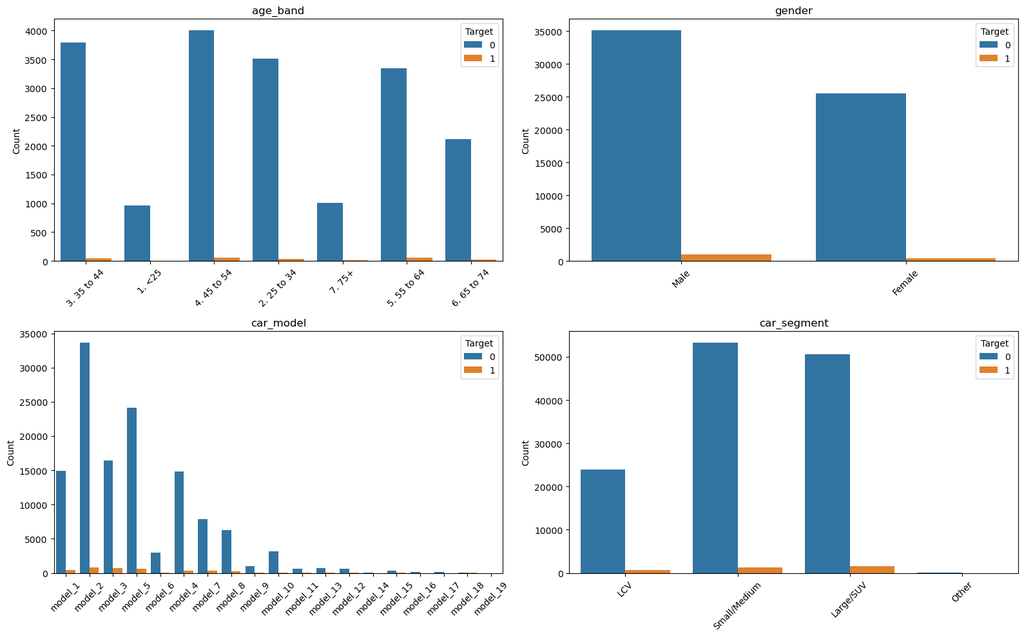

```python
# Selecting categorical features
categorical_features = data.select_dtypes(include=['object'])

# Plotting bar plots for categorical features
plt.figure(figsize=(16, 10))
for i, col in enumerate(categorical_features.columns):
    plt.subplot(2, 2, i + 1)
    sns.countplot(data=data, x=col, hue='Target')
    plt.title(col)
    plt.xlabel('')
    plt.ylabel('Count')
    plt.xticks(rotation=45)
plt.tight_layout()
plt.show()
```

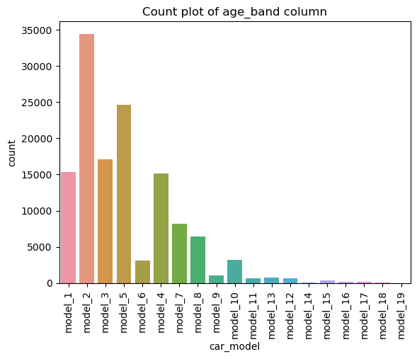

```python
# count plot
sns.countplot(x='car_model', data=data)
sns.set_palette("Set3",10)
plt.title('Count plot of age_band column')
plt.xticks(rotation=90)
plt.show()
```

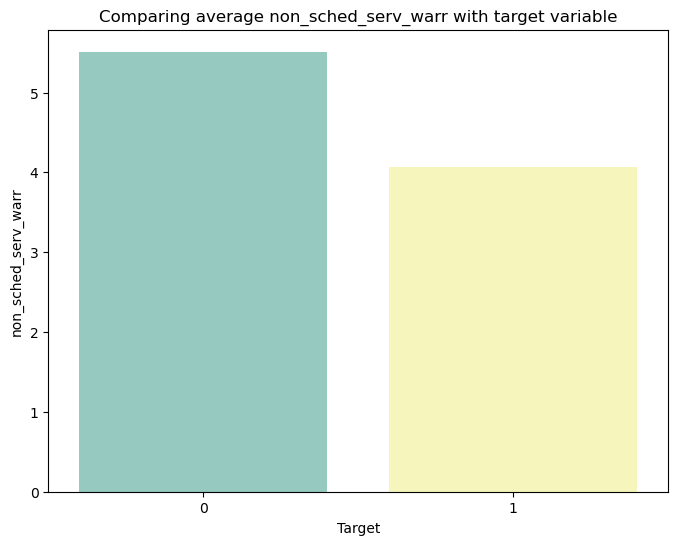

```python
# seaborn bar plot gives the variable average
plt.figure(figsize=(8,6))
sns.barplot(x="Target",y="non_sched_serv_warr",data=data,ci= False)
plt.title("Comparing average non_sched_serv_warr with target variable")
plt.show()
```

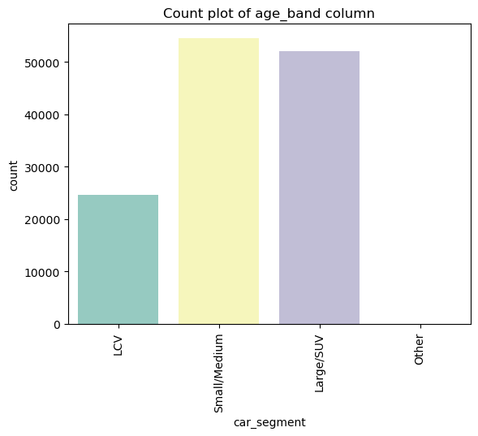

```python
# count plot
sns.countplot(x='car_segment', data=data)
sns.set_palette("Set3",10)
plt.title('Count plot of age_band column')
plt.xticks(rotation=90)
plt.show()
```

```python
# Display descriptive statistics for numerical features
print(data[['age_of_vehicle_years', 'annualised_mileage', 'total_services']].describe())

# For categorical features, to see the frequency of each category
print(data['car_segment'].value_counts())
```

```
       age_of_vehicle_years  annualised_mileage  total_services
count         131337.000000       131337.000000   131337.000000
mean               5.493022            5.502836        5.454967
std                2.843299            2.854896        2.875961
min                1.000000            1.000000        1.000000
25%                3.000000            3.000000        3.000000
50%                5.000000            5.000000        5.000000
75%                8.000000            8.000000        8.000000
max               10.000000           10.000000       10.000000
car_segment
Small/Medium    54553
Large/SUV       52120
LCV             24606
Other              58
Name: count, dtype: int64
```

## 5. Prepare dataset

```python
data.isnull()
```

|  | ID | Target | age_band | gender | car_model | car_segment | age_of_vehicle_years | sched_serv_warr | non_sched_serv_warr | sched_serv_paid | non_sched_serv_paid | total_paid_services | total_services | mth_since_last_serv | annualised_mileage | num_dealers_visited | num_serv_dealer_purchased |
| --- | --- | --- | --- | --- | --- | --- | --- | --- | --- | --- | --- | --- | --- | --- | --- | --- | --- |
| 0 | False | False | False | False | False | False | False | False | False | False | False | False | False | False | False | False | False |
| 1 | False | False | True | True | False | False | False | False | False | False | False | False | False | False | False | False | False |
| 2 | False | False | True | False | False | False | False | False | False | False | False | False | False | False | False | False | False |
| 3 | False | False | True | True | False | False | False | False | False | False | False | False | False | False | False | False | False |
| 4 | False | False | True | False | False | False | False | False | False | False | False | False | False | False | False | False | False |
| ... | ... | ... | ... | ... | ... | ... | ... | ... | ... | ... | ... | ... | ... | ... | ... | ... | ... |
| 131332 | False | False | True | True | False | False | False | False | False | False | False | False | False | False | False | False | False |
| 131333 | False | False | True | True | False | False | False | False | False | False | False | False | False | False | False | False | False |
| 131334 | False | False | True | True | False | False | False | False | False | False | False | False | False | False | False | False | False |
| 131335 | False | False | True | True | False | False | False | False | False | False | False | False | False | False | False | False | False |
| 131336 | False | False | True | True | False | False | False | False | False | False | False | False | False | False | False | False | False |

131337 rows × 17 columns

```python
data.isnull().sum()
```

```
ID                                0
Target                            0
age_band                     112375
gender                        69308
car_model                         0
car_segment                       0
age_of_vehicle_years              0
sched_serv_warr                   0
non_sched_serv_warr               0
sched_serv_paid                   0
non_sched_serv_paid               0
total_paid_services               0
total_services                    0
mth_since_last_serv               0
annualised_mileage                0
num_dealers_visited               0
num_serv_dealer_purchased         0
dtype: int64
```

##### Replacing NaN values in age_band and gender with Unknown

```python
# Assigning a new category for missing values in 'age_band' and 'gender'
data['age_band'].fillna('Unknown', inplace=True)
data['gender'].fillna('Unknown', inplace=True)


data.isnull().sum()
```

```
ID                           0
Target                       0
age_band                     0
gender                       0
car_model                    0
car_segment                  0
age_of_vehicle_years         0
sched_serv_warr              0
non_sched_serv_warr          0
sched_serv_paid              0
non_sched_serv_paid          0
total_paid_services          0
total_services               0
mth_since_last_serv          0
annualised_mileage           0
num_dealers_visited          0
num_serv_dealer_purchased    0
dtype: int64
```

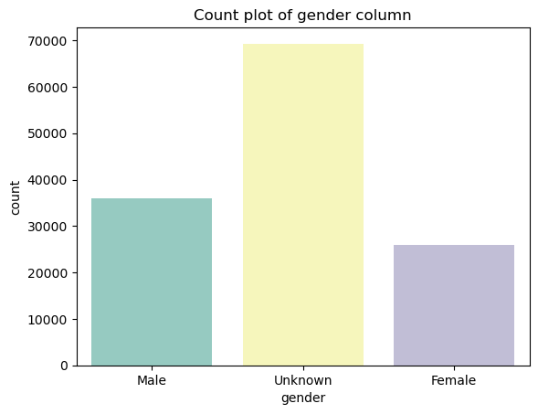

```python
# count plot
sns.countplot(x='gender', data=data)
plt.title('Count plot of gender column')
plt.show()
```

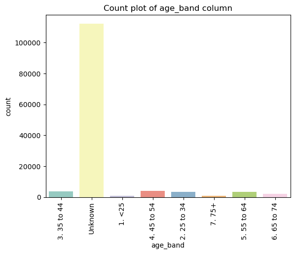

```python
# count plot
sns.countplot(x='age_band', data=data)
sns.set_palette("Set3",10)
plt.title('Count plot of age_band column')
plt.xticks(rotation=90)
plt.show()
```

##### Dropping both as number of unknown values are more than relevent valuesand aslo dropping ID as it will not contribute to the analysis

```python
# dropping the age_band column as it is having alot of null
data.drop('age_band', axis=1, inplace=True)
data.drop('gender', axis=1, inplace=True)
data.drop('ID', axis=1, inplace=True)
```

```python
# check the missing values again
data.isna().sum()
```

```
Target                       0
car_model                    0
car_segment                  0
age_of_vehicle_years         0
sched_serv_warr              0
non_sched_serv_warr          0
sched_serv_paid              0
non_sched_serv_paid          0
total_paid_services          0
total_services               0
mth_since_last_serv          0
annualised_mileage           0
num_dealers_visited          0
num_serv_dealer_purchased    0
dtype: int64
```

##### Result: all the unkown values are dropped for better analysis

#### Selecting features

```python
features=['car_model', 'car_segment',
       'age_of_vehicle_years', 'sched_serv_warr', 'non_sched_serv_warr',
       'sched_serv_paid', 'non_sched_serv_paid',
       'total_services', 'mth_since_last_serv', 'annualised_mileage',
       'num_dealers_visited', 'num_serv_dealer_purchased']
```

```python
data_new = data.copy()

# Initialize the LabelEncoder
le = LabelEncoder()

# Loop through each column in the DataFrame
for column in data_new.columns:
    if data_new[column].dtype == 'object':  # Checking if the column is of type object (string)
        # Apply Label Encoding to the column
        data_new[column] = le.fit_transform(data_new[column])

# Check the transformed data
data_new.head()
```

|  | Target | car_model | car_segment | age_of_vehicle_years | sched_serv_warr | non_sched_serv_warr | sched_serv_paid | non_sched_serv_paid | total_paid_services | total_services | mth_since_last_serv | annualised_mileage | num_dealers_visited | num_serv_dealer_purchased |
| --- | --- | --- | --- | --- | --- | --- | --- | --- | --- | --- | --- | --- | --- | --- |
| 0 | 0 | 0 | 0 | 9 | 2 | 10 | 3 | 7 | 5 | 6 | 9 | 8 | 10 | 4 |
| 1 | 0 | 11 | 3 | 6 | 10 | 3 | 10 | 4 | 9 | 10 | 6 | 10 | 7 | 10 |
| 2 | 0 | 12 | 1 | 9 | 10 | 9 | 10 | 9 | 10 | 10 | 7 | 10 | 6 | 10 |
| 3 | 0 | 12 | 1 | 5 | 8 | 5 | 8 | 4 | 5 | 6 | 4 | 10 | 9 | 7 |
| 4 | 0 | 11 | 3 | 8 | 9 | 4 | 10 | 7 | 9 | 8 | 5 | 4 | 4 | 9 |

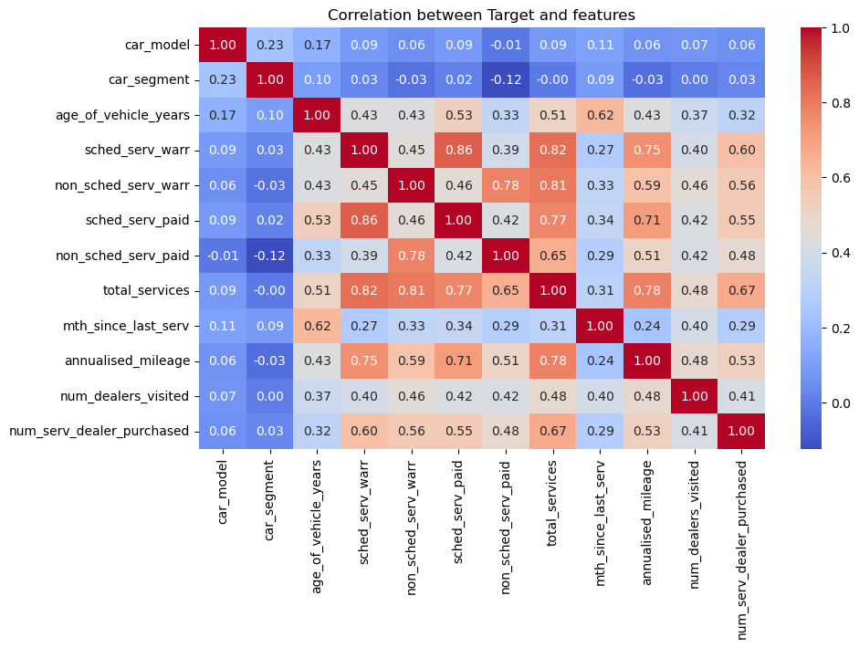

```python
# Calculating correlation matrix
correlation_matrix = data_new[features].corr()

# Plotting the correlation matrix
plt.figure(figsize=(10, 6))
sns.heatmap(correlation_matrix, annot=True, cmap='coolwarm', fmt=".2f")
plt.title('Correlation between Target and features')
plt.show()
```

##### Correlation matrix of selected features

```python
skewness = data_new.skew()
print(skewness)
```

```
Target                       5.859128
car_model                   -1.361417
car_segment                  0.057010
age_of_vehicle_years         0.023906
sched_serv_warr              0.021495
non_sched_serv_warr          0.015396
sched_serv_paid              0.020868
non_sched_serv_paid          0.004243
total_paid_services          0.010846
total_services               0.027122
mth_since_last_serv          0.019794
annualised_mileage           0.000665
num_dealers_visited          0.005518
num_serv_dealer_purchased    0.010470
dtype: float64
```

```python
# Define a threshold
threshold = 1000

# Calculate the frequency of each category
value_counts = data_new['car_model'].value_counts()

# Create a mask for all categories below the threshold
mask = data_new['car_model'].isin(value_counts[value_counts < threshold].index)

# Replace categories below the threshold with 0
data_new['car_model'][mask] = 0
```

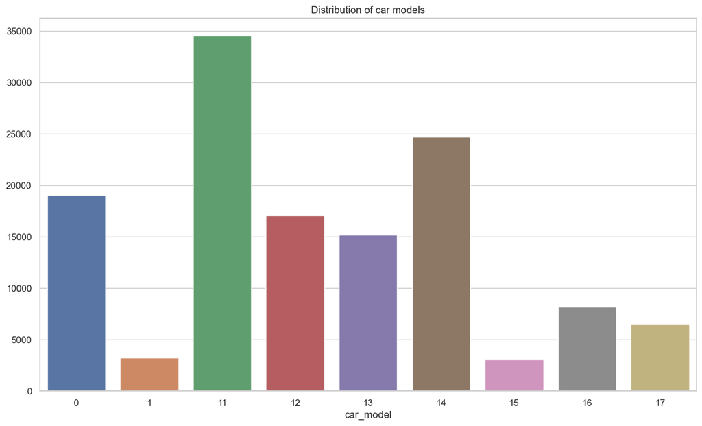

```python
 #Setting plot style and size
sns.set(style="whitegrid")
plt.figure(figsize=(14, 8))

# Distribution of 'car_model'
plt.subplot()
model_counts = data_new['car_model'].value_counts()
sns.barplot(x=model_counts.index, y=model_counts.values)
plt.title('Distribution of car models')
```

```python
data=data_new.copy()
```

## 6.Split data

```python
from sklearn.model_selection import train_test_split
from imblearn.over_sampling import SMOTE

# Define features and target
X = data.drop('Target', axis=1)
y = data['Target']

# Split the data into temporary training+validation (80%) and test (20%)
X_temp, X_test, y_temp, y_test = train_test_split(X, y, test_size=0.2, random_state=42)

# Split the temporary set into actual training (60% of total) and validation (20% of total)
X_train, X_val, y_train, y_val = train_test_split(X_temp, y_temp, test_size=0.25, random_state=42)

print(X_train.shape, X_val.shape, X_test.shape)

# Apply SMOTE only to the training data
smote = SMOTE(random_state=42)
X_train_smote, y_train_smote = smote.fit_resample(X_train, y_train)

# Check the balance in the training set after SMOTE
print('Balanced class distribution:', y_train_smote.value_counts())
```

```
(78801, 13) (26268, 13) (26268, 13)
Balanced class distribution: Target
0    76645
1    76645
Name: count, dtype: int64
```

## 7. **Train Machine Learning Model**

```python
from sklearn.linear_model import LogisticRegression
from sklearn.metrics import accuracy_score, precision_score, recall_score, f1_score, roc_auc_score, classification_report, confusion_matrix

# Initialize the Logistic Regression model
logistic_model = LogisticRegression(random_state=42)

# Train the model on the balanced training data
logistic_model.fit(X_train_smote, y_train_smote)

# Predict on the validation set
y_val_pred = logistic_model.predict(X_val)
y_val_proba = logistic_model.predict_proba(X_val)[:, 1]  # Probabilities for the positive class

# Evaluate the model
accuracy = accuracy_score(y_val, y_val_pred)
precision = precision_score(y_val, y_val_pred)
recall = recall_score(y_val, y_val_pred)
f1 = f1_score(y_val, y_val_pred)
roc_auc = roc_auc_score(y_val, y_val_proba)

print(f"Accuracy: {accuracy}")
print(f"Precision: {precision}")
print(f"Recall: {recall}")
print(f"F1 Score: {f1}")
print(f"ROC AUC Score: {roc_auc}")
print("\nConfusion Matrix:\n", confusion_matrix(y_val, y_val_pred))
print("\nClassification Report:\n", classification_report(y_val, y_val_pred))
```

```
Accuracy: 0.7770290848180296
Precision: 0.09201773835920177
Recall: 0.8241134751773049
F1 Score: 0.1655506482404901
ROC AUC Score: 0.9019166664585867

Confusion Matrix:
 [[19830  5733]
 [  124   581]]

Classification Report:
               precision    recall  f1-score   support

           0       0.99      0.78      0.87     25563
           1       0.09      0.82      0.17       705

    accuracy                           0.78     26268
   macro avg       0.54      0.80      0.52     26268
weighted avg       0.97      0.78      0.85     26268
```

#### Result

Accuracy (77.7%) Precision (9.2% for class 1) Recall (82.4% for class 1) F1 Score (16.6% for class 1) ROC AUC Score (90.2%)

### Confusion Matrix

True Negatives (19830): The model correctly predicted "not re-buy" for a large number of customerFalse Positives (5733): The model incorrectly predicted "re-buy" for many customers who did not actually re-buy False Negatives (124): The model missed a small number of actual re-buys. True Positives (581): The model correctly identified a significant number of re-buys.

#### Hyperparameter Tuning

```python
from sklearn.model_selection import GridSearchCV

# Define the parameter grid
param_grid = {
    'C': [0.01, 0.1, 1, 10, 100],  # Regularization strength
    'solver': ['liblinear', 'lbfgs'],  # Algorithm to use in the optimization problem
    'class_weight': [None, 'balanced']  # Weights associated with classes
}

# Create the grid search object
grid_search = GridSearchCV(estimator=logistic_model, param_grid=param_grid, cv=5, scoring='f1', verbose=1)

# Fit the grid search to the data
grid_search.fit(X_train_smote, y_train_smote)

# Print the best parameters and best score
print("Best parameters found: ", grid_search.best_params_)
print("Best F1 score found: ", grid_search.best_score_)
```

```
Fitting 5 folds for each of 20 candidates, totalling 100 fits
Best parameters found:  {'C': 0.01, 'class_weight': None, 'solver': 'lbfgs'}
Best F1 score found:  0.843824614566621
```

### Assess Model Performance

```python
# Initialize the Logistic Regression model with the best parameters
optimized_logistic_model = LogisticRegression(
    C=grid_search.best_params_['C'],
    solver=grid_search.best_params_['solver'],
    class_weight=grid_search.best_params_['class_weight'],
    random_state=42  # Ensure reproducibility
)

# Train the optimized model on the balanced training data
optimized_logistic_model.fit(X_train_smote, y_train_smote)

# Predict on the test set
y_test_pred = optimized_logistic_model.predict(X_test)
y_test_proba = optimized_logistic_model.predict_proba(X_test)[:, 1]  # Probabilities for the positive class

# Evaluate the optimized model
accuracy_test = accuracy_score(y_test, y_test_pred)
precision_test = precision_score(y_test, y_test_pred)
recall_test = recall_score(y_test, y_test_pred)
f1_test = f1_score(y_test, y_test_pred)
roc_auc_test = roc_auc_score(y_test, y_test_proba)

# Print performance metrics
print(f"Test Accuracy: {accuracy_test}")
print(f"Test Precision: {precision_test}")
print(f"Test Recall: {recall_test}")
print(f"Test F1 Score: {f1_test}")
print(f"Test ROC AUC Score: {roc_auc_test}")
print("\nTest Confusion Matrix:\n", confusion_matrix(y_test, y_test_pred))
print("\nTest Classification Report:\n", classification_report(y_test, y_test_pred))
```

```
Test Accuracy: 0.7819400030455307
Test Precision: 0.08823529411764706
Test Recall: 0.8227272727272728
Test F1 Score: 0.1593777516877018
Test ROC AUC Score: 0.9003925146497779

Test Confusion Matrix:
 [[19997  5611]
 [  117   543]]

Test Classification Report:
               precision    recall  f1-score   support

           0       0.99      0.78      0.87     25608
           1       0.09      0.82      0.16       660

    accuracy                           0.78     26268
   macro avg       0.54      0.80      0.52     26268
weighted avg       0.97      0.78      0.86     26268
```

High Recall, Low Precision: Like our initial results, the model maintains a high recall and low precision for class 1, suggesting it still identifies most of the positive class (people likely to re-buy) but at the cost of a high false positive rate.

Test Accuracy and ROC AUC Score: The accuracy and ROC AUC score remain relatively high, which confirms that the model discriminates between the positive and negative classes effectively over various thresholds.

Confusion Matrix: The confusion matrix shows a large number of false positives, similar to before. This is consistent with the high recall and low precision — the model is classifying a lot of negatives (non re-buyers) as positives (re-buyers).

```python
from sklearn.model_selection import cross_val_score

# Configuring the number of folds and the scoring metric
scores = cross_val_score(logistic_model, X_train_smote, y_train_smote, cv=5, scoring='f1')

print("Cross-Validation F1 Scores:", scores)
print("Average F1 Score:", scores.mean())
```

```
Cross-Validation F1 Scores: [0.83749107 0.84288767 0.84971598 0.84410693 0.84414297]
Average F1 Score: 0.8436689247848241
```

Model Robustness: The consistent F1 scores suggest that the logistic regression model, when trained on the SMOTE-augmented dataset, is robust and reliable.